# Beating the House

[figure not shown]

Mateo Elezi and Elia Martin

CMSC320 Fall 2019

University of Maryland

## Introduction

One industry that has long thrived around the world of professional sports is that of sports betting. With the 2018 overturn of the [Professional and Amateur Sports Protection Act of 1992](https://www.usatoday.com/story/sports/2018/05/14/supreme-court-sports-betting-paspa-law-new-jersey/440710002/) and the advent of the internet, sports betting has recently become more legal and more accessible than ever before in the United States.

This is a hugely important industry, both for the companies racing to make money from bettors and for the millions of Americans spending [more than $150 billion every year](https://www.cnbc.com/2019/04/27/fanduel-draftkings-race-to-win-150-billion-sports-betting-market.html) gambling on sports. As with any type of gambling, the only thing you can be sure of is that the house will always win. But the ease and popularity of sports betting along with news of [recent wagers with enormous payouts](https://www.cbssports.com/nfl/news/super-bowl-2018-somebody-bet-millions-of-dollars-that-the-eagles-will-win-it-all/), it's natural to ask:

**Is it possible to outsmart the crowd (and get rich) by using a model to pick which bets to take?**

We decided to perform our analysis on the National Football League, as football is the sport with the largest betting market outside of European football ([source](https://www.sportsbettingdime.com/guides/finance/global-sports-betting-market/)). There are many ways to place bets on sports, but we chose to focus on two of the most common: Point Spread Betting and Over Under Betting.

### An Introduction to Point Spread and Over Under Betting

(adapted from a more thorough explanation at [OddsShark](https://www.oddsshark.com/sports-betting/point-spread-betting))

In a point spread bet, oddsmakers set a number, called the "spread" for a given matchup that represents a predicted margin of victory for the favored team. Bets are then placed on which team will "cover the spread": for the underdog, this means losing by a smaller margin than the spread or winning; for the favorite, it means winning by more than the spread. Because almost any matchup has a team that is favored to win, adding a point spread evens out the interest that bettors have in wagering for either side.

As an example, here is a point spread for a recent game between the Miami Dolphins and the New York Jets:

**Miami +5.0**

**New York -5.0**

New York was the 5-point favorite, meaning they needed to win the game by 5 points or more to win the bet. As the underdog, Miami needed to either lose by a margin of less than 5 or win the game to win the bet.

The final score of the game was **New York 22-21 Miami**. Because the margin was smaller than 5 points, bets placed on New York for this matchup *lost* even though New York won the game. Miami "covered the spread" because they remained within the margin given by the point spread.

For the same game, oddsmakers can also set an over under figure:

**New York vs Miami O/U 43.5**

Taking the same **New York 22-21 Miami** scoreline, the total points scored is 43 points. Bets placed on the *Under* would then win, because the total score was *under* the figure provided by oddsmakers.

Sometimes when many more bets are being placed for a certain team, sportsbooks will adjust a spread leading up to a game in order to encourage more bets in a certain direction (and ensure that for any result they will make money). If we create a model that predicts NFL margins better than the books, we can take advantage of matchups with underdogs who in reality have a better chance than their spreads reflect.

The success of such a model would be a huge win for data science. It would mean that the NFL betting system can be broken by a well-informed bettor who could then consistently beat other bettors and the house.

We use a variety of accessible python libraries in our analysis, such as [BeautifulSoup](https://www.crummy.com/software/BeautifulSoup/), [Pandas](https://pandas.pydata.org/), [NumPy](https://numpy.org/), [SciPy](https://www.scipy.org/), [Seaborn](https://seaborn.pydata.org/), and [scikit-learn](https://scikit-learn.org/stable/index.html).

```python
# Import libraries to be used later
from bs4 import BeautifulSoup
import requests
import lxml
import pandas as pd
import re
import numpy as np
from scipy import stats
from scipy.stats import linregress
import matplotlib.pyplot as plt
import seaborn as sns
import statsmodels.api as sm

from sklearn.linear_model import LogisticRegression
from sklearn.model_selection import cross_val_score
from sklearn.discriminant_analysis import LinearDiscriminantAnalysis as LDA
from sklearn.model_selection import KFold
from sklearn.metrics import accuracy_score
from sklearn.svm import SVC
from sklearn import tree
from sklearn.neighbors import KNeighborsClassifier
from sklearn.ensemble import RandomForestClassifier

# Ignore future warnings
from warnings import simplefilter
simplefilter(action='ignore', category=FutureWarning)
import warnings
warnings.filterwarnings('ignore')
```

[figure not shown]

## Gathering Data

We can expect the best results when we have statistics from many games on which to base our predictions. Because trades and drafts can change teams dramatically from season to season, the later in the season we look the more informed we can be. We decided to "place our bets" on playoff games, based on team statistics from regular season games.

We scrape yearly regular season team stats from [Pro Football Reference](https://www.pro-football-reference.com/years/2018) using BeautifulSoup:

```python
# Get the page content (with an HTML 'get' request)
site2018 = requests.get('https://www.pro-football-reference.com/years/2018/')
site2017 = requests.get('https://www.pro-football-reference.com/years/2017/')
site2016 = requests.get('https://www.pro-football-reference.com/years/2016/')

# Parse the page as HTML using BeautifulSoup
soup2018 = BeautifulSoup(site2018.content, 'html.parser')
soup2017 = BeautifulSoup(site2017.content, 'html.parser')
soup2016 = BeautifulSoup(site2016.content, 'html.parser')

# Get the html code for all the tables on each page
mytable2018 = soup2018.find_all('table')
mytable2017 = soup2017.find_all('table')
mytable2016 = soup2016.find_all('table')

# Read HTML file into dataframe using Pandas. For each year there is a table
# for the American Football Conference and the National Football Conference.
df_afc2018 = pd.read_html(str(mytable2018))[0]
df_nfc2018 = pd.read_html(str(mytable2018))[1]
df_afc2017 = pd.read_html(str(mytable2017))[0]
df_nfc2017 = pd.read_html(str(mytable2017))[1]
df_afc2016 = pd.read_html(str(mytable2016))[0]
df_nfc2016 = pd.read_html(str(mytable2016))[1]
```

In order to check out the relationship between these stats and playoff point spreads, we need to know results and point spread values for playoff games. Odds Shark offers this data in its [NFL Football Odds & Handicapping Database](https://www.oddsshark.com/nfl/database), but it only allows for queries of individual teams. So we manually copied each team's entries for postseason games from the 2016-17 season to 2018-19 into our own csv file and import it here:

```python
playoff_data = pd.read_csv("nfl_playoffs_2017-19.csv", sep=',')
```

[figure not shown]

## Preprocessing

The regular season stats come in six separate tables, split by year and conference. We first remove formatting rows that do not contain team stats, combine them into one big dataframe, and add a column identifying the year:

```python
# Drop the "east" "north" "south" "west" label rows
df_afc2018.drop([0,5,10,15], axis=0, inplace=True)
df_nfc2018.drop([0,5,10,15], axis=0, inplace=True)
df_afc2017.drop([0,5,10,15], axis=0, inplace=True)
df_nfc2017.drop([0,5,10,15], axis=0, inplace=True)
df_afc2016.drop([0,5,10,15], axis=0, inplace=True)
df_nfc2016.drop([0,5,10,15], axis=0, inplace=True)

# Combine tables by year
frames2018 = [df_afc2018, df_nfc2018]
result2018 = pd.concat(frames2018)
frames2017 = [df_afc2017, df_nfc2017]
result2017= pd.concat(frames2017)
frames2016 = [df_afc2016, df_nfc2016]
result2016= pd.concat(frames2016)

# Add a column representing the year in which the season ends (the 2018-19 season becomes 2019)
result2018['Year_End'] = 2019
result2017['Year_End'] = 2018
result2016['Year_End'] = 2017

# Combine all years into one dataframe
frames_final = [result2018, result2017, result2016]
season_stats= pd.concat(frames_final)
```

[figure not shown]

## Tidying

Before we begin exploring this data, we need to fix it up. This is what our season stats from Pro Football Reference look like right now:

```python
season_stats.head()
```

|  | DSRS | L | MoV | OSRS | PA | PD | PF | SRS | SoS | T | Tm | W | W-L% | Year_End |
| --- | --- | --- | --- | --- | --- | --- | --- | --- | --- | --- | --- | --- | --- | --- |
| 1 | 2.1 | 5 | 6.9 | 3.1 | 325 | 111 | 436 | 5.2 | -1.8 | 0 | New England Patriots* | 11 | .688 | 2019 |
| 2 | -5.2 | 9 | -7.1 | -3.6 | 433 | -114 | 319 | -8.8 | -1.7 | 0 | Miami Dolphins | 7 | .438 | 2019 |
| 3 | -0.6 | 10 | -6.6 | -6.3 | 374 | -105 | 269 | -6.9 | -0.3 | 0 | Buffalo Bills | 6 | .375 | 2019 |
| 4 | -5.9 | 12 | -6.8 | -2.0 | 441 | -108 | 333 | -7.8 | -1.1 | 0 | New York Jets | 4 | .250 | 2019 |
| 6 | 6.4 | 6 | 6.4 | 0.6 | 287 | 102 | 389 | 7.0 | 0.6 | 0 | Baltimore Ravens* | 10 | .625 | 2019 |

The "Tm" column currently contains the full team name along with some symbols (*, +) indicating division winners, wild cards, and other details we don't care about. Instead of the full team names, we want to use the same abbreviations that the Odds Shark table uses (ATL for Atlanta Falcons, BAL for Baltimore Ravens, etc.) so they can be merged later. This table also includes some statistics we won't be using, like Wins, Losses, and Ties. We replace each name entry with its abbreviation, give columns more descriptive names and drop the ones we won't use:

```python
def clean_names(team):
    # Search for opening bracket in the name followed by
    # any characters repeated any number of times
    if re.search('(\*|\+)', team):

        # Extract the position of beginning of pattern
        pos = re.search('(\*|\+)', team).start()

        # return the cleaned name
        team = team[:pos]

    if team == "New England Patriots":
        return "NE"
    if team == "Atlanta Falcons":
        return "ATL"
    if team == "Baltimore Ravens":
        return "BAL"
    if team == "Buffalo Bills":
        return "BUF"
    if team == "Carolina Panthers":
        return "CAR"
    if team == "Chicago Bears":
        return "CHI"
    if team == "Dallas Cowboys":
        return "DAL"
    if team == "Green Bay Packers":
        return "GB"
    if team == "Houston Texans":
        return "HOU"
    if team == "Indianapolis Colts":
        return "IND"
    if team == "Jacksonville Jaguars":
        return "JAC"
    if team == "Kansas City Chiefs":
        return "KC"
    if team == "Los Angeles Rams":
        return "LAR"
    if team == "Los Angeles Chargers":
        return "LAC"
    if team == "San Diego Chargers":
        return "LAC"
    if team == "Miami Dolphins":
        return "MIA"
    if team == "Minnesota Vikings":
        return "MIN"
    if team == "New Orleans Saints":
        return "NO"
    if team == "New York Giants":
        return "NYG"
    if team == "Oakland Raiders":
        return "OAK"
    if team == "Philadelphia Eagles":
        return "PHI"
    if team == "Pittsburgh Steelers":
        return "PIT"
    if team == "Seattle Seahawks":
        return "SEA"
    if team == "Tennessee Titans":
        return "TEN"
    if team == "New York Jets":
        return "NYJ"
    if team == "Arizona Cardinals":
        return "ARI"
    if team == "San Francisco 49ers":
        return "SF"
    if team == "Washington Redskins":
        return "Was"
    if team == "Cleveland Browns":
        return "CLE"
    if team == "Tampa Bay Buccaneers":
        return "TB"
    if team == "Detroit Lions":
        return "DET"
    if team == "Cincinnati Bengals":
        return "CIN"
    if team == "Denver Broncos":
        return "DEN"

    # if no clean up is needed, return the same name
    return team

# Run the function defined above
season_stats['Tm'] = season_stats['Tm'].apply(clean_names)

# Rename columns
season_stats = season_stats.rename(columns={"Tm": "Team", "Year_End": "Year"})

# Drop columns we won't use
season_stats.drop(columns=["PD", "PF", "PA", "T", "W", "L"], inplace=True)
```

After tidying, here's what this table looks like. Better!

```python
season_stats.head()
```

|  | DSRS | MoV | OSRS | SRS | SoS | Team | W-L% | Year |
| --- | --- | --- | --- | --- | --- | --- | --- | --- |
| 1 | 2.1 | 6.9 | 3.1 | 5.2 | -1.8 | NE | .688 | 2019 |
| 2 | -5.2 | -7.1 | -3.6 | -8.8 | -1.7 | MIA | .438 | 2019 |
| 3 | -0.6 | -6.6 | -6.3 | -6.9 | -0.3 | BUF | .375 | 2019 |
| 4 | -5.9 | -6.8 | -2.0 | -7.8 | -1.1 | NYJ | .250 | 2019 |
| 6 | 6.4 | 6.4 | 0.6 | 7.0 | 0.6 | BAL | .625 | 2019 |

Now let's tidy our playoff data. Here's what our playoff spread table from Odds Shark looks like right now:

```python
playoff_data.head()
```

|  | Date | Away | Score | Home | Score.1 | Result | Home Spread | ATS | Total | OU |
| --- | --- | --- | --- | --- | --- | --- | --- | --- | --- | --- |
| 0 | 13-Jan-18 | ATL | 10 | PHI | 15 | L | 2.5 | L | 40.5 | U |
| 1 | 6-Jan-18 | ATL | 26 | LAR | 13 | W | -6.0 | W | 48.0 | U |
| 2 | 5-Feb-17 | NE | 34 | ATL | 28 | L | 3.0 | L | 57.5 | O |
| 3 | 22-Jan-17 | GB | 21 | ATL | 44 | W | -6.5 | W | 59.5 | O |
| 4 | 14-Jan-17 | SEA | 20 | ATL | 36 | W | -6.5 | W | 51.0 | O |

For this analysis we don't particularly care about the exact date of each game, but we will want to separate by year, so let's replace the Date column with just the Year. We'll also give the Score columns more descriptive names.

```python
# Add Year column
playoff_data.insert(1, "Year", 0)

# Populate year column based on Date column
for i, r in playoff_data.iterrows():
    playoff_data.set_value(i,"Year", 2000 + int(r["Date"][-2:]))

# Add more descriptively named score columns
playoff_data.rename(columns={"Score": "Away Score", "Score.1": "Home Score"}, inplace=True)
```

The data we got from Odds Shark was by team, so it listed every match twice. Having two entries for each match will confound our analysis, so we delete duplicate entries. We now have 33 rows (11 playoff games per season * 3 seasons) in this dataframe.

```python
# Drop duplicate rows
playoff_data.drop_duplicates(subset=["Year", "Away", "Home"], inplace=True)

# Reset index
playoff_data.reset_index(inplace=True)

# Reorder columns
playoff_data = playoff_data[['Year', 'Home', 'Home Score', 'Away', 'Away Score', 'Result', 'Home Spread', 'ATS', 'OU','Total']]
```

Here's how the playoff data looks after tidying. Ready for analysis!

```python
playoff_data.head()
```

|  | Year | Home | Home Score | Away | Away Score | Result | Home Spread | ATS | OU | Total |
| --- | --- | --- | --- | --- | --- | --- | --- | --- | --- | --- |
| 0 | 2018 | PHI | 15 | ATL | 10 | L | 2.5 | L | U | 40.5 |
| 1 | 2018 | LAR | 13 | ATL | 26 | W | -6.0 | W | U | 48.0 |
| 2 | 2017 | ATL | 28 | NE | 34 | L | 3.0 | L | O | 57.5 |
| 3 | 2017 | ATL | 44 | GB | 21 | W | -6.5 | W | O | 59.5 |
| 4 | 2017 | ATL | 36 | SEA | 20 | W | -6.5 | W | O | 51.0 |

[figure not shown]

## Exploratory Data Analysis

### Adding our own data

Since we care about point spreads and the Over/Under, two characteristics we'll be looking at for each match are its point differential (the home team's score minus the away team's score) and point total (the home team's score plus the away team's score). We add a column for each to the playoff data.

```python
playoff_data.insert(6, "Point Differential", 0)
playoff_data.insert(7, "Point Total", 0)


playoff_data['Home Score'] = pd.to_numeric(playoff_data['Home Score'])
playoff_data['Away Score'] = pd.to_numeric(playoff_data['Away Score'])

for i, r in playoff_data.iterrows():
    playoff_data.set_value(i,"Point Differential", r['Home Score'] - r['Away Score'])
    playoff_data.set_value(i,"Point Total", r['Home Score'] + r['Away Score'])
```

We want to analyze the playoff data informed by the relevant regular season data, so we merge the two tables.

```python
# Merge stats along Home team
season_stats.rename(columns={"Team":"Home"}, inplace=True)
all_data = pd.merge(playoff_data, season_stats)

# Merge stats along Away team
away_season_stats = season_stats.copy(deep=True)
away_season_stats.rename(columns={"Home":"Away","SRS":"Away SRS","DSRS":"Away DSRS","MoV":"Away MoV","OSRS":"Away OSRS","SoS":"Away SoS","W-L%":"Away W-L%"}, inplace=True)


all_data = pd.merge(all_data, away_season_stats)
all_data.head()
```

|  | Year | Home | Home Score | Away | Away Score | Result | Point Differential | Point Total | Home Spread | ATS | ... | OSRS | SRS | SoS | W-L% | Away DSRS | Away MoV | Away OSRS | Away SRS | Away SoS | Away W-L% |
| --- | --- | --- | --- | --- | --- | --- | --- | --- | --- | --- | --- | --- | --- | --- | --- | --- | --- | --- | --- | --- | --- |
| 0 | 2018 | PHI | 15 | ATL | 10 | L | 5 | 25 | 2.5 | L | ... | 7.0 | 9.4 | -0.7 | .813 | 3.2 | 2.4 | 1.1 | 4.3 | 1.9 | .625 |
| 1 | 2018 | LAR | 13 | ATL | 26 | W | -13 | 39 | -6.0 | W | ... | 8.2 | 9.2 | -0.2 | .688 | 3.2 | 2.4 | 1.1 | 4.3 | 1.9 | .625 |
| 2 | 2018 | PHI | 38 | MIN | 7 | L | 31 | 45 | 3.0 | L | ... | 7.0 | 9.4 | -0.7 | .813 | 6.8 | 8.1 | 2.3 | 9.1 | 1.0 | .813 |
| 3 | 2017 | ATL | 28 | NE | 34 | L | -6 | 62 | 3.0 | L | ... | 10.5 | 8.5 | 0.1 | .688 | 5.0 | 11.9 | 4.3 | 9.3 | -2.7 | .875 |
| 4 | 2017 | ATL | 44 | GB | 21 | W | 23 | 65 | -6.5 | W | ... | 10.5 | 8.5 | 0.1 | .688 | -2.0 | 2.8 | 4.9 | 2.8 | 0.1 | .625 |

5 rows × 24 columns

Now, we can define and apply functions to change the values in the "Result," "OU," and "ATS" columns, respectively representing the result of selecting the home team to win the game, selecting the home team to beat the spread, and predicting that the total points scored will be greater than the over/under value. We turn these values into ones and zeros, a better labeling system for numeric and logistic analysis later.

```python
# A function which returns 0 if the result was a loss for the home team, or 1 if it was a win for the home team
def label_result (row):
    if pd.to_numeric(row['Home Score']) < pd.to_numeric(row['Away Score']) :
        return 0
    if pd.to_numeric(row['Home Score']) > pd.to_numeric(row['Away Score']) :
        return 1
    #To avoid errors, a -1 is returned if the data is misread, which would alert us to any problems through errors later on
    return -1

# A function which returns 0 if the under was achieved, or 1 if it was not achieved
def label_OU (row):
    if pd.to_numeric(row['Point Total']) < pd.to_numeric(row['Total']) :
        return 0
    if pd.to_numeric(row['Point Total']) > pd.to_numeric(row['Total']) :
        return 1
    #To avoid errors, a -1 is returned if the data is misread, which would alert us to any problems through errors later on
    return -1

# A function which returns 0 if the home team did not cover the spread, or 1 if ithe home team did cover the spread
def label_spread (row):
    if pd.to_numeric(row['Home Score']) + pd.to_numeric(row['Home Spread']) < pd.to_numeric(row['Away Score']) :
        return 0
    if pd.to_numeric(row['Home Score']) + pd.to_numeric(row['Home Spread']) > pd.to_numeric(row['Away Score']) :
        return 1
    #To avoid errors, a -1 is returned if the data is misread, which would alert us to any problems through errors later on
    return -1

# We apply the function to each row, and store the returned results in the appropriate columns,
# replacing the original letter-based representation
all_data['ATS'] = all_data.apply (lambda row: label_spread(row), axis=1)
all_data['OU'] = all_data.apply (lambda row: label_OU(row), axis=1)
all_data['Result'] = all_data.apply (lambda row: label_result(row), axis=1)
```

With these new columns, we can now begin to analyze the data.

### Visualizing our current data

We start by looking at the relationship between various regular season team metrics and the point spread of playoff games.

```python
# We will create a single figure, with 6 (2 columns x 3 rows) graphs on it, for easier comparison
fig, axs = plt.subplots(ncols=2, nrows=3)
# We manually increase the size of our entire figure, so that the individual graphs are more visible
fig.set_size_inches(15, 15)

#The following code segment is repeated 6 times, but we will only comment the first one

# For the W-L% (Win-loss percent)
# Change W-L% and Away W-L% to numeric data
all_data["W-L%"] = pd.to_numeric(all_data["W-L%"])
all_data["Away W-L%"] = pd.to_numeric(all_data["Away W-L%"])
# Create a column which represents the difference in these statistics
all_data["W-L% Dif"] = all_data["W-L%"] - all_data["Away W-L%"]
# Plot this difference against the spread, at position (0,0) - Top left
WLSpread = sns.regplot(x="W-L% Dif", y = "Point Differential", data=all_data, ax=axs[0][0])
# Set the title of this individual graph
WLSpread.set_title("Spread vs. W-L% Difference")


# For MoV (Margin of Victory)
all_data["MoV"] = pd.to_numeric(all_data["MoV"])
all_data["Away MoV"] = pd.to_numeric(all_data["Away MoV"])
all_data["MoV Dif"] = all_data["MoV"] - all_data["Away MoV"]
MoVSpread = sns.regplot(x="MoV Dif", y = "Point Differential", data=all_data, ax=axs[0][1])
MoVSpread.set_title("Spread vs. MoV Difference")

# For SRS (Simple Rating System)
all_data["SRS"] = pd.to_numeric(all_data["SRS"])
all_data["Away SRS"] = pd.to_numeric(all_data["Away SRS"])
all_data["SRS Dif"] = all_data["SRS"] - all_data["Away SRS"]
SRSSpread = sns.regplot(x="SRS Dif", y = "Point Differential", data=all_data, ax=axs[1][0])
SRSSpread.set_title("Spread vs. SRS")

# For OSRS (Offensive Simple Rating System)
all_data["OSRS"] = pd.to_numeric(all_data["OSRS"])
all_data["Away OSRS"] = pd.to_numeric(all_data["Away OSRS"])
all_data["OSRS Dif"] = all_data["OSRS"] - all_data["Away OSRS"]
OSRSSpread = sns.regplot(x="OSRS Dif", y = "Point Differential", data=all_data, ax=axs[1][1])
OSRSSpread.set_title("Spread vs. OSRS")

# For DSRS (Defensive Simple Rating System)
all_data["DSRS"] = pd.to_numeric(all_data["DSRS"])
all_data["Away DSRS"] = pd.to_numeric(all_data["Away DSRS"])
all_data["DSRS Dif"] = all_data["DSRS"] - all_data["Away DSRS"]
DSRSSpread = sns.regplot(x="DSRS Dif", y = "Point Differential", data=all_data, ax=axs[2][0])
DSRSSpread.set_title("Spread vs. DSRS")

# For SoS (Strength of Schedule)
all_data["SoS"] = pd.to_numeric(all_data["SoS"])
all_data["Away SoS"] = pd.to_numeric(all_data["Away SoS"])
all_data["SoS Dif"] = all_data["SoS"] - all_data["Away SoS"]
SoSSpread = sns.regplot(x="SoS Dif", y = "Point Differential", data=all_data, ax=axs[2][1])
SoSSpread.set_title("Spread vs. SoS")
```

[output not shown]

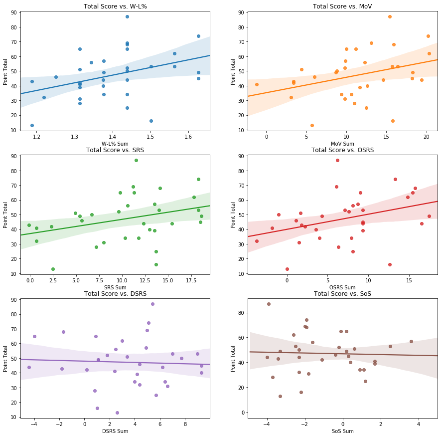

```python
# This process is the same as in the last code segment save 2 differences:
# 1. Instead of using difference (for calculating point difference), we are now using the sum (to calculate point total)
# 2. Instead of plotting against Point Difference, we now plot against Point Total
fig, axs = plt.subplots(ncols=2, nrows=3)
fig.set_size_inches(15, 15)

all_data["W-L% Sum"] = all_data["W-L%"] + all_data["Away W-L%"]
WLTot = sns.regplot(x="W-L% Sum", y = "Point Total", data=all_data, ax=axs[0][0])
WLTot.set_title("Total Score vs. W-L%")

all_data["MoV Sum"] = all_data["MoV"] + all_data["Away MoV"]
MoVTot = sns.regplot(x="MoV Sum", y = "Point Total", data=all_data, ax=axs[0][1])
MoVTot.set_title("Total Score vs. MoV")

all_data["SRS Sum"] = all_data["SRS"] + all_data["Away SRS"]
SRSTot = sns.regplot(x="SRS Sum", y = "Point Total", data=all_data, ax=axs[1][0])
SRSTot.set_title("Total Score vs. SRS")

all_data["OSRS Sum"] = all_data["OSRS"] + all_data["Away OSRS"]
OSRSTot = sns.regplot(x="OSRS Sum", y = "Point Total", data=all_data, ax=axs[1][1])
OSRSTot.set_title("Total Score vs. OSRS")

all_data["DSRS Sum"] = all_data["DSRS"] + all_data["Away DSRS"]
SRSTot = sns.regplot(x="DSRS Sum", y = "Point Total", data=all_data, ax=axs[2][0])
SRSTot.set_title("Total Score vs. DSRS")

all_data["SoS Sum"] = all_data["SoS"] + all_data["Away SoS"]
SoSTot = sns.regplot(x="SoS Sum", y = "Point Total", data=all_data, ax=axs[2][1])
# We manually adjust the x-axis here, as the provided scale was less than ideal given the domain of the data
SoSTot.set(xlim=(-5,5))
SoSTot.set_title("Total Score vs. SoS")
```

In this go around, we look at the sum of the two teams statistics for a variety of measures. Much like before, we use this because the total points scored is the sum of the points scored by each team, so we have decided to look at the sum of the statistics of each team.

The data above tells us quite a bit. For starters, we can see that DSRS and SoS seem to have almost no relation to the point total or the spread. The other four, SRS, OSRS, MoV, and W-L% seem to be much more representative. However, since OSRS is used in the calculation of SRS, we decided to eliminate OSRS. Ultimately, we settled on W-L%, SRS, and MoV as our categories of interest. Narrowing the categories we select is especially important for our data, because we have little playoff data, making the risk of overfitting even higher.

### Creating a Model

Having settled on the data we want to use to build a model, we can now move on to implementing it. We now use the data we have chosen to build 3 logistic models to predict the spread result, the over/under result, and the winner of the game.

```
[(0, 1)]
```

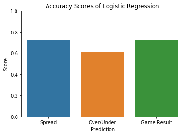

```python
# Select relevant outcome data (spread, over/under, and result)
# To use sklearn's logistic regression, this data must be reformatted into an array of arrays, using reshape
Y_Spread = all_data.iloc[:, 9].values.reshape(-1, 1)
Y_OverUnder = all_data.iloc[:, 10].values.reshape(-1, 1)
Y_Result = all_data.iloc[:, 5].values.reshape(-1, 1)

# Select the aforementioned regular season data
X = all_data.iloc[:, [13, 15, 17, 19, 21, 23]].values

# Create a logistic regression on each betting category using regular season data
# We use liblinear as the solver because it is suited to smaller data sets
SpreadReg = LogisticRegression(solver="liblinear").fit(X,Y_Spread)
OUReg = LogisticRegression(solver="liblinear").fit(X,Y_OverUnder)
ResultReg = LogisticRegression(solver="liblinear").fit(X,Y_Result)

# We create a dataframe of the fit scores for each model
headers=["Spread", "Over/Under","Game Result"]
scores = [SpreadReg.score(X, Y_Spread), OUReg.score(X, Y_OverUnder), ResultReg.score(X, Y_Result)]
list_of_tuples = list(zip(headers, scores))
logistic_fit = pd.DataFrame(list_of_tuples, columns = ['Prediction', 'Score'])

# We create a bar graph showing the fit score for each prediction
score_plot = sns.barplot(x='Prediction',y='Score',data=logistic_fit)
score_plot.set_title("Accuracy Scores of Logistic Regression")
score_plot.set(ylim=(0,1))
```

From the above graph, we can see that our model is a better fit for the data when looking at spread and the result of the game, and slightly worse when trying to predict the over or under.

### Generating Machine Learning Models for Comparison

Since we are using python, we have access not only to logistic regression, but also a wide array of machine learning models. Let's put a few to use. In the following section, we will fit a few machine learning models to our data, and perform an analysis of the accuracy of the machine learning models, and our logistic regression model.

```
[(0, 1)]
```

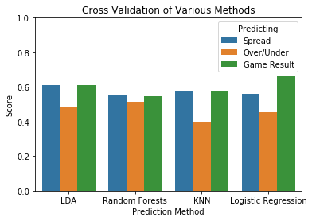

```python
# Initializing a variety of machine learning methods and the logistic regression from earlier
lda = LDA()
forest = RandomForestClassifier()
KNN = KNeighborsClassifier()
LogReg = LogisticRegression()
cv_variable=3

# Here we calculate three cross validation score for each method above using the same data for the logistic
# regression. For each method we calculate a mean score for the three predictions: spread, over/under, and game result
SpreadLdaScore = cross_val_score(lda,X,Y_Spread,cv=cv_variable)
OULdaScore = cross_val_score(lda,X,Y_OverUnder,cv=cv_variable)
ResultLdaScore = cross_val_score(lda,X,Y_Result,cv=cv_variable)

SpreadForestScore = cross_val_score(forest,X,Y_Spread,cv=cv_variable)
OUForestScore = cross_val_score(forest,X,Y_OverUnder,cv=cv_variable)
ResultForestScore = cross_val_score(forest,X,Y_Result,cv=cv_variable)

SpreadKNNScore = cross_val_score(KNN,X,Y_Spread,cv=cv_variable)
OUKNNScore = cross_val_score(KNN,X,Y_OverUnder,cv=cv_variable)
ResultKNNScore = cross_val_score(KNN,X,Y_Result,cv=cv_variable)

SpreadLogScore = cross_val_score(LogReg,X,Y_Spread,cv=cv_variable)
OULogScore = cross_val_score(LogReg,X,Y_OverUnder,cv=cv_variable)
ResultLogScore = cross_val_score(LogReg,X,Y_Result,cv=cv_variable)

# We package all of the data into a dataframe
test_type=["LDA","LDA","LDA","Random Forests","Random Forests","Random Forests","KNN","KNN","KNN","Logistic Regression","Logistic Regression","Logistic Regression"]
headers=["Spread", "Over/Under","Game Result","Spread", "Over/Under","Game Result","Spread", "Over/Under","Game Result","Spread", "Over/Under","Game Result"]
scores = [SpreadLdaScore.mean(), OULdaScore.mean(), ResultLdaScore.mean(), SpreadForestScore.mean(), OUForestScore.mean(),ResultForestScore.mean(), SpreadKNNScore.mean(), OUKNNScore.mean(), ResultKNNScore.mean(), SpreadLogScore.mean(), OULogScore.mean(), ResultLogScore.mean()]
list_of_tuples = list(zip(test_type, headers, scores))
ML_fit = pd.DataFrame(list_of_tuples, columns = ['Prediction Method', 'Predicting', 'Score' ])

# We generate a plot to display our scores
MLscore_plot = sns.barplot(x='Prediction Method',y='Score',hue='Predicting',data=ML_fit)
MLscore_plot.set_title("Cross Validation of Various Methods")
MLscore_plot.set(ylim=(0,1))
```

The data above gives us a test of the accuracy of models through a K-fold test, which essentially splits the data into k random sets, trains the data on k-1 sets, and applies it to the unused set to check for accuracy. It does k times, cycling through each set as the testing set, and using all combinations of k-1 sets as training sets. We then take the mean of these scores, and plot the above. Due to the nature of this test (splitting randomly), we cannot give any analysis of the data, as with each run of the program it is subject to change, sometimes dramatically.

### Model Relation

Now, we will use T-tests to see if any of these models stand out from eachother. Specifically, we will run a test which will tell us the likelihood that the accuracy scores found in the previous section came from different samples.

```
[(0, 1)]
```

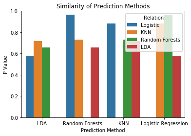

```python
# We generate p-values for the comparison between the kfold tests for each combination of two methods
LDALOG= stats.ttest_rel(SpreadLdaScore,SpreadLogScore).pvalue
LDAKNN= stats.ttest_rel(SpreadLdaScore,SpreadKNNScore).pvalue
LDAFOR= stats.ttest_rel(SpreadLdaScore,SpreadForestScore).pvalue
LOGKNN = stats.ttest_rel(SpreadKNNScore,SpreadLogScore).pvalue
LOGFOR = stats.ttest_rel(SpreadForestScore,SpreadLogScore).pvalue
FORKNN = stats.ttest_rel(SpreadKNNScore,SpreadForestScore).pvalue

# We pack all of the data into a dataframe
test_type=["LDA","LDA","LDA","Random Forests","Random Forests","Random Forests","KNN","KNN","KNN","Logistic Regression","Logistic Regression","Logistic Regression"]
headers=["Logistic", "KNN","Random Forests","LDA", "Logistic","KNN","LDA", "Logistic","Random Forests","LDA", "Random Forests","KNN",]
scores = [LDALOG, LDAKNN, LDAFOR, LDAFOR, LOGFOR,FORKNN, LDAKNN, LOGKNN, FORKNN, LDALOG, LOGFOR, LOGKNN]
pdvals = list(zip(test_type, headers, scores))
pVals = pd.DataFrame(pdvals, columns = ['Prediction Method', 'Relation', 'P Value' ])

# We generate a plot to display our scores
MLscore_plot = sns.barplot(x='Prediction Method',y='P Value',hue='Relation',data=pVals)
MLscore_plot.set_title("Similarity of Prediction Methods")
MLscore_plot.set(ylim=(0,1))
```

For T-tests, we have a null hypothesis, in this case that the KFold accuracy tests these models produce come from different samples. For the most part, there seems to be little reason to reject the null hypothesis, as the chances two sets of accuracy scores came from the same sample is never low enough to raise doubt. Therefore, functionally, we cannot reject the idea that these models are very similar.

## Coefficient P-Value

Because we these models are similar enough that we fail to reject that their accuracy scores could come from the same population, and due to the great simplicity of testing logistic regression coefficient p-values, we decided to use our logistic model to get an idea of the importance of our input variables. We do this by calculating the p-value of each coefficient, with the null hypothesis representing that the coefficient is zero.

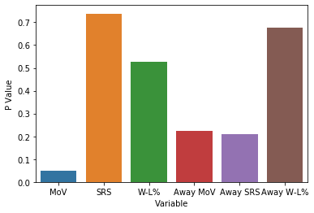

```python
sm_model = sm.Logit(Y_Spread, sm.add_constant(X)).fit(disp=0)
scores = ["MoV", "SRS", "W-L%", "Away MoV", "Away SRS","Away W-L%"]
pdcoef = list(zip(scores, sm_model.pvalues))
pdCoef = pd.DataFrame(pdcoef, columns = ['Variable', 'P Value' ])
sns.barplot(x='Variable',y='P Value',data=pdCoef)
```

Our data shows that the only input variable of significant importance (significant enough to reject that it could simply be 0) is MoV. Also of relative importance was Away MoV and Away SRS. SRS, W-L%, and Away W-L% all had very high p-values, leading us to fail to reject the null hypothesis.

## Placing our bets

Now that we have generated a few models, and gone through the process of testing them randomly, we can test them for their true purpose: gambling!

```python
# First we split the data into a training set (2017-2018) and a testing set (2019)
data_1718 = all_data[all_data["Year"] != 2019]
data_19 = all_data[all_data["Year"] == 2019]

# We acquire the same input and output data as for the original model, limiting ourselves to 2017-2018
Y_Spread1718 = data_1718.iloc[:, 9].values.reshape(-1, 1)
Y_OU1718 = data_1718.iloc[:, 10].values.reshape(-1, 1)
Y_Result1718 = data_1718.iloc[:, 5].values.reshape(-1, 1)
X = data_1718.iloc[:, [13,15,17,19,21,23]].values
X2019 = data_19.iloc[:, [13,15,17,19,21,23]].values


# We apply the same model to only 2017-2018 data
SpreadReg1718 = LogisticRegression(solver="liblinear").fit(X,Y_Spread1718)
OUReg1718 = LogisticRegression(solver="liblinear").fit(X,Y_OU1718)
ResultReg1718 = LogisticRegression(solver="liblinear").fit(X,Y_Result1718)

SpreadLDA1718 = LDA().fit(X,Y_Spread1718)
OULDA1718 = LDA().fit(X,Y_OU1718)
ResultLDA1718 = LDA().fit(X,Y_Result1718)

SpreadFor1718 = RandomForestClassifier().fit(X,Y_Spread1718)
OUFor1718 = RandomForestClassifier().fit(X,Y_OU1718)
ResultFor1718 = RandomForestClassifier().fit(X,Y_Result1718)

SpreadKNN1718 = KNeighborsClassifier().fit(X,Y_Spread1718)
OUKNN1718 = KNeighborsClassifier().fit(X,Y_OU1718)
ResultKNN1718 = KNeighborsClassifier().fit(X,Y_Result1718)

# We use the 2017-2018 model, along with 2019 season stats to try to predict the 2019 playoff game betting results
data_19['Logistic Spread'] = SpreadReg1718.predict(X2019)
data_19['Logistic OU'] = OUReg1718.predict(X2019)
data_19['Logistic Result'] = ResultReg1718.predict(X2019)
data_19['LDA Spread'] = SpreadLDA1718.predict(X2019)
data_19['LDA OU'] = OULDA1718.predict(X2019)
data_19['LDA Result'] = ResultLDA1718.predict(X2019)
data_19['Forest Spread'] = SpreadFor1718.predict(X2019)
data_19['Forest OU'] = OUFor1718.predict(X2019)
data_19['Forest Result'] = ResultFor1718.predict(X2019)
data_19['KNN Spread'] = SpreadKNN1718.predict(X2019)
data_19['KNN OU'] = OUKNN1718.predict(X2019)
data_19['KNN Result'] = ResultKNN1718.predict(X2019)
```

# Results

With four prediction methods, and three variables to predict, there is a lot to unpack here.

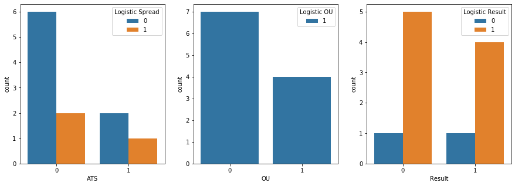

```python
# We create a 3x1 matrix of plots to store our predictions for each logistic regression
fig2, axs2 = plt.subplots(ncols=3, nrows=1)
fig2.set_size_inches(15, 5)

# We use a countplot, split by what the actual result is, which counts the number of ones and zeros we picked
# This gives us a count of the
sns.countplot(x="ATS", hue = "Logistic Spread",data=data_19,ax=axs2[0])
sns.countplot(x="OU", hue = "Logistic OU",data=data_19, ax=axs2[1])
sns.countplot(x="Result", hue="Logistic Result",data=data_19, ax=axs2[2])
```

Beginning with our logistic regression, we see that we perform quite well in predicting the spread for the away team (AT=0), and slightly less so for the home team (AT=1). For the over/under, our model results in only over selections, which is a very poor fit as the majority of the games (7 vs 4) end up falling in the under range. In predicting the result of the game, the logistic regression also does very poorly, producing practically the same chart for wins and losses, although compared to the over/under chart, this is preferable as we hit on 5 games instead of 4.

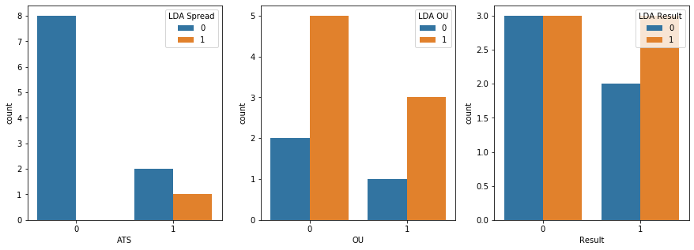

```python
fig3, axs3 = plt.subplots(ncols=3, nrows=1)
fig3.set_size_inches(15, 5)

sns.countplot(x="ATS", hue = "LDA Spread",data=data_19,ax=axs3[0])
sns.countplot(x="OU", hue = "LDA OU",data=data_19, ax=axs3[1])
sns.countplot(x="Result", hue="LDA Result",data=data_19, ax=axs3[2])
```

Moving on, we see that our LDA method heavily favors the away side to cover the spread, predicting 10/11 games to go to the away team. It hits on 8 of these 10, and the one game it favored the home team in. For the LDA over/under chart, we see relatively similar charts regardless of the actual outcome, leading to 5 hits and 6 misses. LDA essentially repeats this performance for picking the winner, giving us a 6 hit, 5 miss performance.

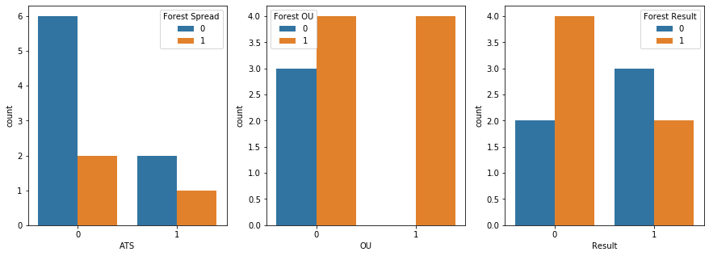

```python
fig4, axs4 = plt.subplots(ncols=3, nrows=1)
fig4.set_size_inches(15, 5)
sns.countplot(x="ATS", hue = "Forest Spread",data=data_19,ax=axs4[0])
sns.countplot(x="OU", hue = "Forest OU",data=data_19, ax=axs4[1])
sns.countplot(x="Result", hue="Forest Result",data=data_19, ax=axs4[2])
```

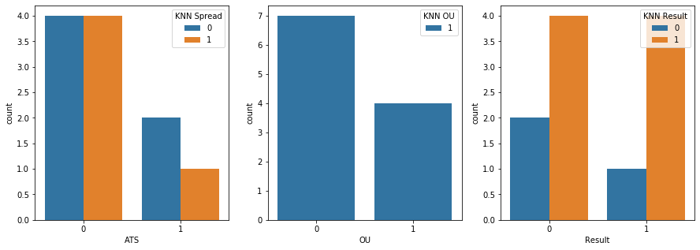

```python
fig5, axs5 = plt.subplots(ncols=3, nrows=1)
fig5.set_size_inches(15, 5)
sns.countplot(x="ATS", hue = "KNN Spread",data=data_19,ax=axs5[0])
sns.countplot(x="OU", hue = "KNN OU",data=data_19, ax=axs5[1])
sns.countplot(x="Result", hue="KNN Result",data=data_19, ax=axs5[2])
```

Finally, our K Neighbors model generally struggles, giving us 5 accurate predictions for the spread, with a plot that shows no areas of strength. For the over/under predictions, the model again struggles, predicting all wins, giving it a poor 4 accurate predictions. It does little to make up for this in predicting the game winner, landing correctly 6/11 times, although it does perform well in games that resulted in wins.

[figure not shown]

## Conclusion

In this project, we set out to use statistics and machine learning to gain the upper hand on Vegas and the world of sports betting. We hoped to find a space between the initial projections by oddsmakers and the betting habits of the public, in order to turn a profit. However, despite our best efforts, even our most successful models provided us with results marginally better than flipping a coin and saying your prayers. However, our inability to draw create a successful model does not serve as an indictment of the ability to use stats in sports betting. We have only explored a narrow slice of the NFL betting world, and with a select few variables. It is very possible that there is a metric which would provide newfound accuracy to our models. Furthermore, it is possible, likely even, that with more data, we would be able to make better selections.

In the end, it seems that the old adage is true; The house always wins. For now.